# Food waste in a simulated food chain

One common issue with household food waste is that people often don’t pay attention to expiration dates on the items they purchase. As a result, they end up throwing out food that has gone bad. One way to reduce this type of waste is to be more mindful of expiration dates and to avoid buying items that are about to expire.  
I want to simulate what happens to the supply chain when consumers or intermediaries prefer items with the longest expiration dates. Is this an effective way to reduce household waste or does it just move waste elsewhere in the supply chain?

Our simulation shows that if consumers pay careful attention to expiration dates, it could result in more waste as food sits on store shelves and expires there. To avoid losing profits, the supply chain will adapt by lowering inventory targets. We show that by keeping inventories low, the supply chain forces consumers to choose from what is available rather than what is fresher, cancelling the benefits of more careful consumption.  
Furthermore, we show that changing inventory targets also affects the supply chain’s risk exposure to demand shocks. When demand shocks are small, supply chains with customers who are selective about expiration dates may produce more waste. However, when demand shocks are large and last for a long time, supply chains with larger inventories (i.e. where customers and intermediaries just buy the oldest items first) may end up producing even more waste.

## Scenario with 20 days perishability

This simulation is purely theoretical and mostly uses numerical parameters from Broekmeulen & van Donselaar(2009).  
The supply chain is made of four echelons (each represented by one agent) plus final consumers which are just stochastic:

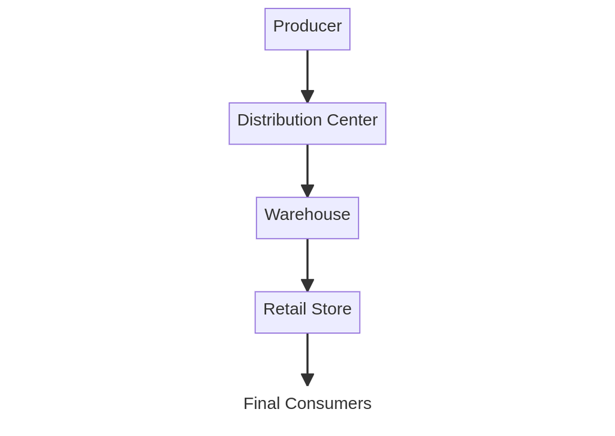

The supply chain structure for this example; each row is represented by one agent except for the final consumers which are just stochastic

The supply chain works as follows:

- From the time the item is produced upstream it has 20 days before it expires
- Final demand is gamma distributed, mean daily demand is 14 items a day, CV is 0.25
- No holding costs, no stockout costs - Items cost 1$ to produce and sell to final consumers for 1.5$
- There is a 1 day delivery lag between each echelon
- All firms use a base order policy, that is they make an order every time step so that their current inventory plus their total orders are equal to their inventory target

Let’s consider the simplest scenario first: all firms sell their oldest items first, following the FIFO (First in, First out) approach. In the plot below, we show how total profits vary for a FIFO supply chain as we change the inventory targets (assuming they are the same at all levels of the supply chain). The profit curve has a wide peak because any inventory target between 42 (3 days’ worth of demand) and 98 (7 days’ worth of demand) leads to maximum profits. Maintaining smaller inventories would mean not being able to meet customer demand consistently, while larger inventories would result in items expiring before they can be consumed.

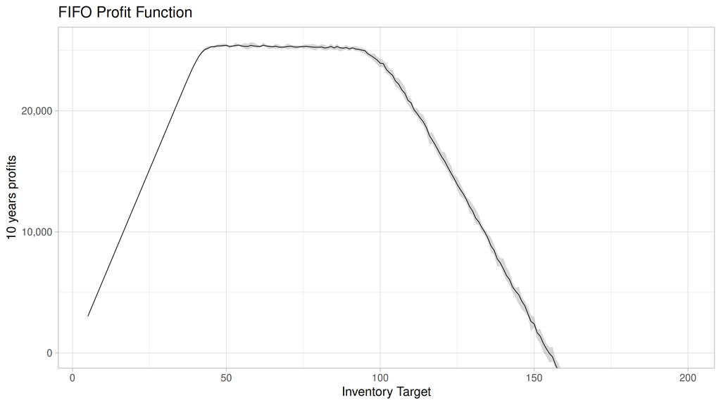

Profit curve for the supply chain. The curve is generated by simulating the supply chain for 10 years with constant inventory targets. For each inventory target, 10 separate simulations were run. The curve shows the average 10-year profit from these simulations, and the ribbon represents the highest and lowest profits simulated for each inventory target.

Optimal inventory targets in FIFO supply chains produce minimal waste. However, if the same targets are used in a LIFO supply chain where consumers or all firms prioritize items with the farthest expiration dates, many items will expire on store shelves. This occurs because any item that isn’t quickly sold to consumers and remains on store shelves will grow older and become even less likely to be bought in the following days. If consumers use LIFO, waste occurs at the retail level; if all firms in the supply chain use LIFO, waste occurs everywhere but remains concentrated downstream as retail need to buy more items to replace those that expire.  
In the figure below, we show an example inventory profile when the supply chain uses an optimal inventory target of 80 units at each level. Waste appears in the retail part of the supply chain for consumer-LIFO scenarios and throughout the supply chain for LIFO-only supply chains.

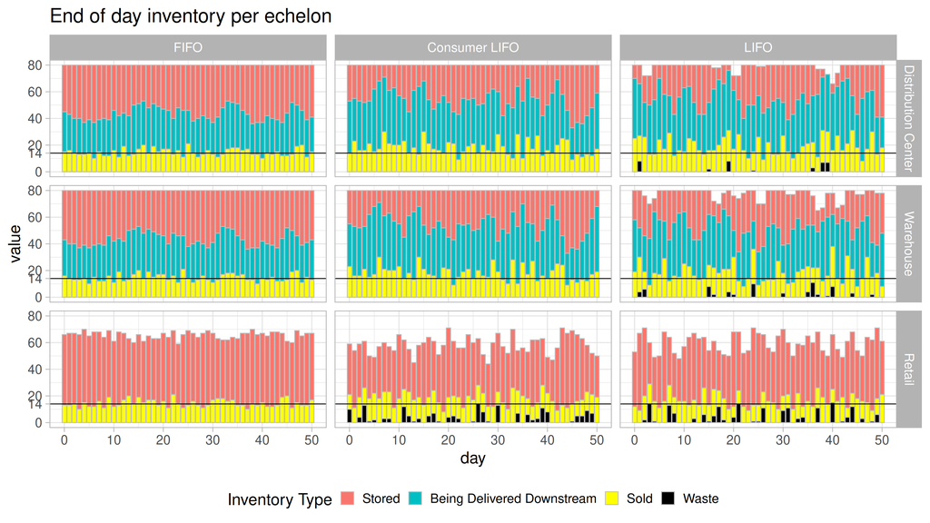

Inventory profiles for the final three levels of the supply chain. The graphs show the inventory at the end of each day in each element of the supply chain. Each column represents a different simulation where the supply chain moves items downstream using either FIFO or LIFO. Each row represents a supply chain level. Waste occurs at the retail level when only consumers use LIFO to purchase products. Waste appears at all levels when every level of the supply chain uses LIFO.

The number of total sales to final consumers within a ten year simulation compared against the number of items that were wasted because they expired before being bought. In this simulation the inventory target for all elements within the supply chain was 80. This is optimal for FIFO supply chains but generate large amount of waste in the other scenarios

Sales simulation

| Scenario | Sold | Waste | Waste % |
| --- | --- | --- | --- |
| FIFO | 51,117 | 35 | 0.1% |
| Consumer LIFO | 50,995 | 13,442 | 26.4% |
| LIFO | 50,952 | 19,768 | 38.8% |

We can confirm that using FIFO targets in LIFO scenarios is not effective by comparing the profit functions. Whenever customers or the entire supply chain prefer to only buy the freshest items (using a LIFO strategy), the profit function becomes single-peaked at precisely 42 items, which is the expected demand for the next three days, or in other words, it is the expected demand over the lead time. This effectively creates a “just in time” system, where every element of the chain holds only what is, on average, demanded over the time it takes to receive a new order from their suppliers. By keeping inventories as low as possible, each element of the supply chain reduces the risk of holding on to unsold, expiring items.  
Even after implementing a just in time strategy, LIFO supply chains do not achieve as high profits as FIFO ones.

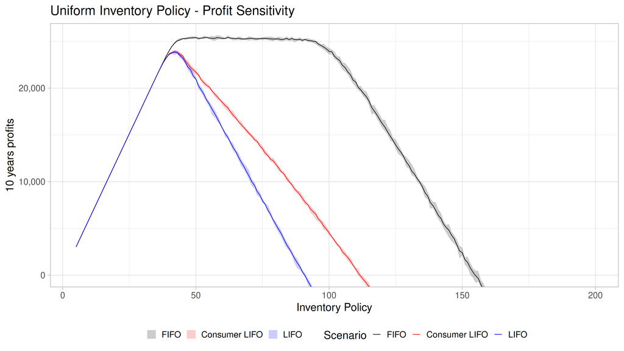

Profit curves for the supply chain, depending on which echelon buys items from their supplier using FIFO or LIFO. The consumer LIFO curve represents a supply chain where consumers buy the freshest items first, but the rest of the supply chain is buying the oldest items first. The LIFO curve shows the profits when every echelon buys the newest items first from their suppliers. The curves are generated by simulating the supply chain for 10 years with constant inventory targets. For each inventory target, 10 separate simulations were run. The curve shows the average 10-year profit from these simulations, and the ribbon represents the highest and lowest profits simulated for each inventory target.

Because of its asymmetric nature, there is a way to improve the performance of a supply chain where only the final consumers prefer buying fresher items. We can discover this by using a genetic algorithm to optimize simulated profits by individually adjusting the inventory targets of each level (a 3-dimensional optimization problem). The algorithm suggests the peak of the profit function shown above for both FIFO and full LIFO supply chains. However, when only consumers use LIFO strategies, the supply chain can increase profits by keeping most inventory in the warehouse instead of the retail level.  
By keeping the retail level low on inventory and restocking it with the oldest items first, the supply chain can minimize waste and force customers to keep buying the oldest items first.  
Specifically, the optimal inventory target levels are 50 for the distribution center, 81 for the warehouse, and 32 for the final store. This works because it ensures there is nearly always enough inventory to cover a day’s worth of trade in the final store, but very little left at the end of each day (usually less than 14, the expected number of daily customers) As a result, most final customers do not have a choice of item freshness; only a few fresh items are available, and the rest are the oldest items the warehouse could deliver the night before. This supply chain response works by removing the ability of customers of buying fresher items, defeating our attempt to reduce household waste.

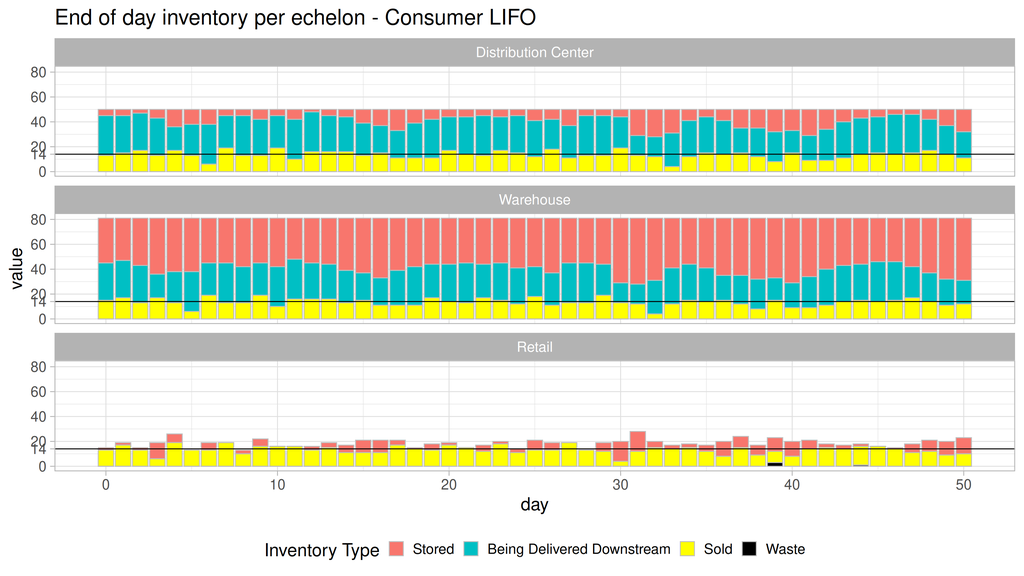

Inventory profiles for the final three levels of the supply chain for one simulation where the final consumers buy the freshest items first but the rest of the chain follows FIFO rules. The height of the bar charts represents the total inventory available at the end each day. Each graph represents a supply chain level. The supply chain follows the optimal policy, with most inventory at the warehouse ready to resupply retail with the oldest items. Retail sells almost all of its inventory daily, leaving few items on the shelves and maximizing the chances of them being purchased in the following days.

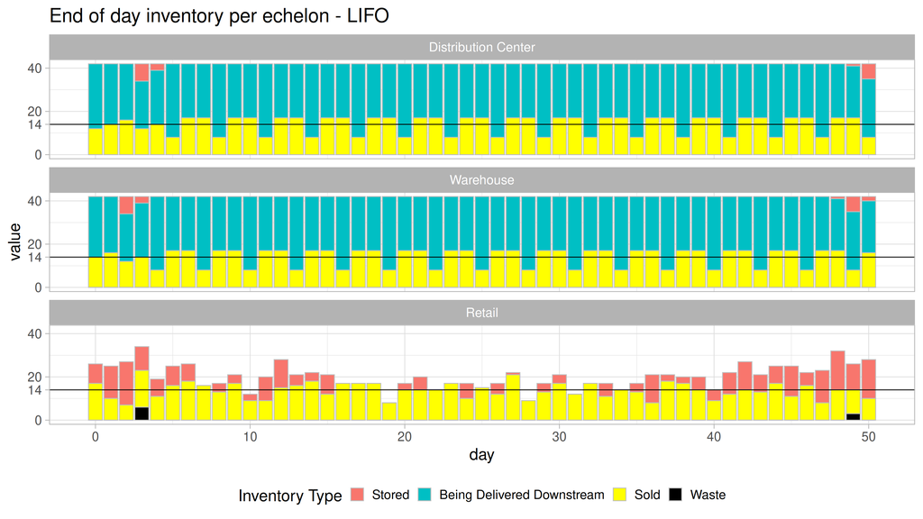

Inventory profiles for the final three levels of the supply chain for one simulation where every level of the supply chain prioritizes buying the freshest inputs The height of the bar charts represents the total inventory available at the end each day. Each graph represents a level of the supply chain. The supply chain follows the optimal policy with every echelon targeting 42 items of inventory. This means that most items are being delivered downstream, giving buyers very little choice in item freshness and forcing them to accept what is available.

To summarize, if buyers prioritize buying items with longer expiration dates, waste will accumulate in the supply chain. The supply chain can adapt by changing inventory levels to prevent items from expiring unsold. However, this undermines the goal of reducing final consumers’ household waste by making them more aware of expiration dates. Facing these customers, the supply chain will modify inventories available to them such that buyers’ choices will again be limited to the oldest items.  
While we have shown that supply chains can minimize waste by adjusting their inventory targets, we will show in the next section that these strategies expose the supply chain to different risks when it experiences a demand shock.

## ショック!

As we saw in the previous section,we can optimize the supply chain’s inventory depending on whether buyers prioritize freshest items. While each strategy is optimal “on average,” they generate different amounts of waste when facing demand shocks. With small shocks (in duration or size), LIFO supply chains generate some waste while FIFO supply chains avoid it entirely. However, during large, long-lasting shocks, FIFO supply chains generate far more waste as FIFO supply chains hold larger inventories. These are at risk of expiring in bulk when facing a long period of low demand. In contrast, LIFO supply chains have limited inventories, so the worst-case scenario involves fewer expiring items within the supply chain. This is shown in the next figure.

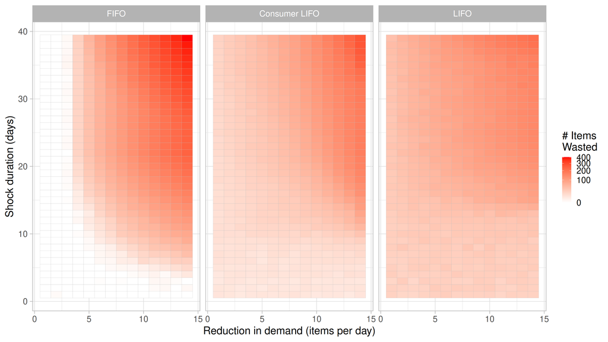

Number of expiring items in the supply chain inventory during demand shocks. The tile plot shows the result of simulating the supply chain for 10 years and then subjecting it to a constant demand (0-14 items, shown on the x-axis) for a fixed number of days (1-40, shown on the y-axis) at the beginning of the 11th year. The total number of wasted items in the final simulated year is collected and plotted. For each combination of scenario, demand reduction, and shock duration, the simulation is run 10 times and the average waste is plotted.

It’s worth examining in detail how a large demand shock (no final consumer for 40 simulated days) affects the supply chains differently. A common feature in all three scenarios is that while the demand stops for 40 days downstream, this is transformed into a two-pulse shock upstream. This is because, while the retail level sees no customers for 40 days, it eventually needs to start replacing expired products. The suppliers upstream experience a short demand shock followed by a new constant stream of outflow to replace waste downstream. In the FIFO scenario, the waste is concentrated entirely at the lowest level of the supply chain. This is because the supply chain pushes the items closest to expiration downstream first. In the Consumer LIFO scenario, the waste occurs in the warehouse as well because that is where most of the items are stored, and only a few items at a time can be moved downstream. In LIFO, there is less waste because the overall inventories are smaller, but some of the items expire upstream because downstream clients prefer fresher items instead.

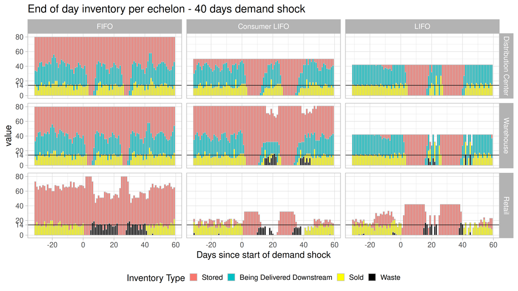

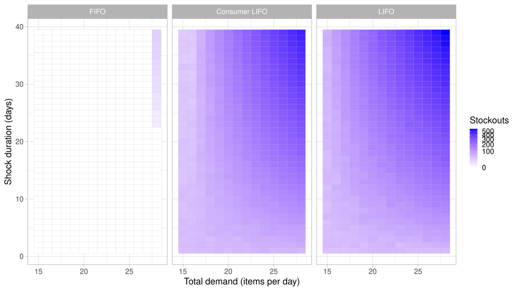

Number of final consumers who are turned away due to a lack of items in the retail level of the supply chain inventory during a demand shock. The tile plot shows the result of simulating the supply chain for 10 years and then subjecting it to a high constant demand (15-29 items, shown on the x-axis) for a fixed number of days (1-40, shown on the y-axis) at the beginning of the 11th year. The total number of consumers turned away (defined as stockouts) in the final simulated year is collected and plotted. For each combination of scenario, demand reduction, and shock duration, the simulation is run 10 times, and the average number of stockouts is plotted.

## super summary

1. To prevent household waste you may want consumers to pay attention to expiration dates and only buy the freshest items
2. This will however result in more items expiring upstream in the supply chain
3. To maximize profits, supply chains can adapt by keeping inventories small
4. With small inventories, consumers are forced back into buying old items
5. Lower inventories tend to increase losses

## References

Broekmeulen, Rob A.C.M., and Karel H. van Donselaar. ‘A Heuristic to Manage Perishable Inventory with Batch Ordering, Positive Lead-Times, and Time-Varying Demand’. Computers & Operations Research 36, no. 11 (November 2009): 3013–18. https://doi.org/10.1016/j.cor.2009.01.017.